# Chamela Adaptation Session 2

# Stochastic Linear Ornstein-Uhlenbeck models for Comparative Hypotheses

Let’s suppose the predictor is not a discrete regime mapping, but a continuous predictor. Here we have salamander data where temperatures were taken at two scales: The temperature of a salamander in its microhabitat and the “macroscale” temperature obtained for species via their geographic coordinates as mean average annual temperature from the BIOCLIM data raster.

```r
library(slouch)
library(treeplyr)

salDat <- readRDS("../data/SalamanderMicrohabitat.rds")
salDat
```

```
$phy

Phylogenetic tree with 26 tips and 25 internal nodes.

Tip labels:
  Desmognathus_wrighti, Desmognathus_imitator, Desmognathus_carolinensis, Desmognathus_ocoee, Desmognathus_orestes, Desmognathus_ochrophaeus, ...

Rooted; includes branch lengths.

$dat
```

| Genus_species | Temp_macro_ave | Temp_macro_errVar | Soil_temp_ave | Soil_temp_errVar |
| --- | --- | --- | --- | --- |
| Desmognathus_wrighti | 11.86471 | 0.21749446 | 14.550588 | 0.21749446 |
| Desmognathus_imitator | 11.68000 | 0.97026667 | 14.360000 | 0.97026667 |
| Desmognathus_carolinensis | 13.30000 | 5.21444445 | 11.533333 | 5.21444445 |
| Desmognathus_ocoee | 11.72000 | 1.90895833 | 15.625000 | 1.90895833 |
| Desmognathus_orestes | 12.86571 | 0.03151293 | 16.142857 | 0.03151293 |
| Desmognathus_ochrophaeus | 11.52667 | 0.22312934 | 12.752083 | 0.22312934 |
| Plethodon_serratus | 14.79077 | 0.53414362 | 11.176923 | 0.53414362 |
| Plethodon_cinereus | 13.22148 | 0.06923594 | 13.122593 | 0.06923594 |
| Plethodon_hoffmani | 14.06556 | 0.26732934 | 13.038889 | 0.26732934 |
| Plethodon_nettingi | 9.54000 | 1.20751111 | 7.573333 | 1.20751111 |

[output cut: 16 more lines]

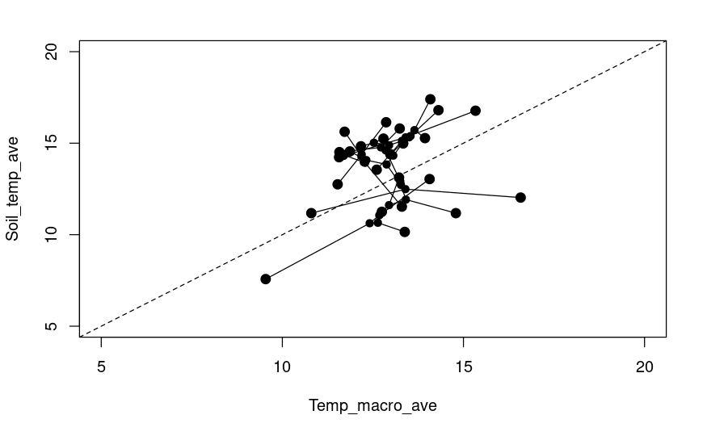

```r
phytools::phylomorphospace(salDat$phy, as.matrix(salDat$dat[,c("Temp_macro_ave", "Soil_temp_ave")]), xlim=c(5, 20), ylim=c(5, 20), ftype="off")
abline(0,1, lty=2) # One to one line
```

```r
library(phylolm)
rownames(salDat$dat) <- salDat$phy$tip.label
pgls_fit <- phylolm(Soil_temp_ave ~ Temp_macro_ave, data=salDat$dat, phy = salDat$phy, model = "OUfixedRoot")
summary(pgls_fit)
```

```
Call:
phylolm(formula = Soil_temp_ave ~ Temp_macro_ave, data = salDat$dat,
    phy = salDat$phy, model = "OUfixedRoot")

   AIC logLik
112.45 -52.22

Raw residuals:
    Min      1Q  Median      3Q     Max
-4.3392 -1.6611  0.6535  1.2929  2.6409

Mean tip height: 82.296
Parameter estimate(s) using ML:
alpha: 0.03924876
sigma2: 0.3684509

Coefficients:
               Estimate  StdErr t.value p.value
(Intercept)     5.93973 3.16760  1.8752 0.07299 .
Temp_macro_ave  0.62608 0.23655  2.6467 0.01413 *
---
Signif. codes:  0 ‘***’ 0.001 ‘**’ 0.01 ‘*’ 0.05 ‘.’ 0.1 ‘ ’ 1

R-squared: 0.2259   Adjusted R-squared: 0.1937

Note: p-values and R-squared are conditional on alpha=0.03924876.
```

Now let’s fit a SLOUCH model. The first one we will fit will actually just repeat the previous exercise, and be another way of fitting a PGLS.

```r
library(slouch)
slouchpgls_fit <- slouch.fit(salDat$phy, species=salDat$phy$tip.label, response = salDat[['Soil_temp_ave']], direct.cov = salDat[['Temp_macro_ave']], hillclimb = TRUE)

summary(slouchpgls_fit)
```

```
Important - Always inspect the likelihood surface of the model parameters with
          grid search before evaluating model fit & results.

  Maximum-likelihood estimates
                       Estimate
Phylogenetic half-life 17.66054
Stationary variance    4.693818

  Inferred maximum-likelihood parameters
                                    Value
Mean phylogenetic correction factor 0.7026479
Rate of adaptation                  0.03924835
Diffusion variance                  0.3684492

  Intercepts
            Estimates Std. error
(Intercept)  5.939715   3.043333

  Direct-effect slope
                           Estimates Std. error
salDat[["Temp_macro_ave"]]  0.626078  0.2272725

  Model fit summary
            Values
Support    -52.200
AIC        112.000
AICc       114.000
SIC        117.000
R squared    0.226
SST         33.600
SSE         26.000
N (params)   4.000
```

Next, we will allow the predictor to be a `random covariate`, or a predictor that evolves via Brownian Motion that has an effect on the primary optimum. We will now obtain two regressions, and “evolutionary regression” corresponding to the realized relationship, and an “optimal regression” representing what?

```r
slouch_fit <- slouch.fit(salDat$phy, species=salDat$phy$tip.label, response = salDat[['Soil_temp_ave']], random.cov = salDat[['Temp_macro_ave']], hillclimb = TRUE)

summary(slouch_fit)
```

```
Important - Always inspect the likelihood surface of the model parameters with
          grid search before evaluating model fit & results.

  Maximum-likelihood estimates
                       Estimate
Phylogenetic half-life 17.42184
Stationary variance    3.988817

  Stochastic predictor(s)
                           Phylogenetic mean Diffusion variance
salDat[["Temp_macro_ave"]]          13.06356          0.1868095

  Inferred maximum-likelihood parameters
                                    Value
Mean phylogenetic correction factor 0.706144
Rate of adaptation                  0.03978611
Diffusion variance                  0.317399

  Interval of parameters in 3d plot (Sensitive to grid mesh, grid size and local ML estimate)
                        Minimum  Maximum
Phylogenetic half-life 57.10652 57.10652
Stationary variance     4.93565  4.93565

  Intercepts
            Estimates Std. error
(Intercept)  6.148522   3.076633

  Optimal regression slope
                           Estimates Std. error
salDat[["Temp_macro_ave"]] 0.8661237  0.3240338

  Evolutionary regression slope
                           Predictions Std. error
salDat[["Temp_macro_ave"]]    0.611608  0.2288145

  Model fit summary
            Values
Support    -52.300
AIC        113.000
AICc       115.000
SIC        118.000
R squared    0.217
SST         33.000
SSE         25.800
N (params)   4.000
```

So far we have ignored measurement error. What do you predict the effect will be of measurement error on: 1. Phylogenetic signal? 2. How will error in Y affect the slope? 3. How will error in X affect the slope?

```r
slouchme_fit <- slouch.fit(salDat$phy, species=salDat$phy$tip.label, response = salDat[['Soil_temp_ave']], mv.response = salDat[['Soil_temp_errVar']],
                           random.cov = salDat[['Temp_macro_ave']], mv.random.cov = salDat[['Temp_macro_errVar']], hillclimb = TRUE)

summary(slouchme_fit)
```

```
Important - Always inspect the likelihood surface of the model parameters with
          grid search before evaluating model fit & results.

  Maximum-likelihood estimates
                       Estimate
Phylogenetic half-life 25.11605
Stationary variance    3.233614

  Stochastic predictor(s)
                           Phylogenetic mean Diffusion variance
salDat[["Temp_macro_ave"]]          13.10279          0.1149756

  Inferred maximum-likelihood parameters
                                    Value
Mean phylogenetic correction factor 0.6051358
Rate of adaptation                  0.02759778
Diffusion variance                  0.1784811

  Intercepts
            Estimates Std. error
(Intercept)  6.534988   2.999001

  Optimal regression slope
                           Estimates Std. error
salDat[["Temp_macro_ave"]] 0.9803003  0.3656455

  Evolutionary regression slope
                           Predictions Std. error
salDat[["Temp_macro_ave"]]   0.5932149  0.2212652

  Attenuation factor. Linear model coefficients (above) are not corrected for bias.

(Intercept)                1 -0.949
salDat[["Temp_macro_ave"]] 0  1.080

  Model fit summary
           Values
Support    -51.60
AIC        111.00
AICc       113.00
SIC        116.00
R squared    0.22
SST         32.70
SSE         25.50
N (params)   4.00
```

Now let’s plot the optimal and evolutionary regressions.

```r
plot(salDat[['Temp_macro_ave']], salDat[['Soil_temp_ave']], xlim=c(5, 20), ylim=c(5,20), xlab="Macroscale Temperature", ylab="Microhabitat Temperature")
abline(slouchme_fit$beta_primary$coefficients_bias_corr[1,1], slouchme_fit$beta_primary$coefficients_bias_corr[2,1], col="green", lwd=2)
```

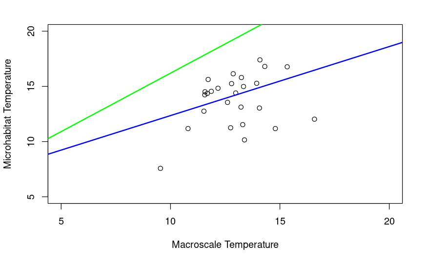

```r
abline(slouchme_fit$beta_evolutionary$coefficients_bias_corr[1,1], slouchme_fit$beta_evolutionary$coefficients_bias_corr[2,1], col="blue", lwd=2)
```

Let’s inspect the likelihood surface. This is a key step to understanding the uncertainty in your parameters. We will show the surface two log likelihood units below the peak, as this allows us to determine the well-supported regions of parameter space.

```r
hls <- seq(0.0001, 300, length.out=40)
vys <- seq(0.01, 25, length.out=40)

slouch_gridsearch <- slouch.fit(salDat$phy, species=salDat$phy$tip.label, response = salDat[['Soil_temp_ave']], mv.response = salDat[['Soil_temp_errVar']],
                           random.cov = salDat[['Temp_macro_ave']], mv.random.cov = salDat[['Temp_macro_errVar']], hl_values = hls, vy_values = vys)
```

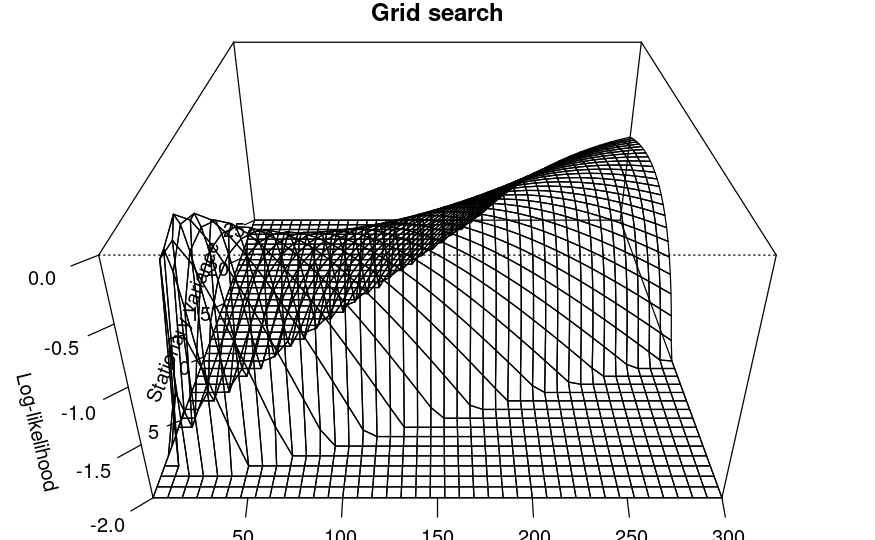

```r
par(mar=c(1,1,1,1))
plot(slouch_gridsearch, theta=0)
```

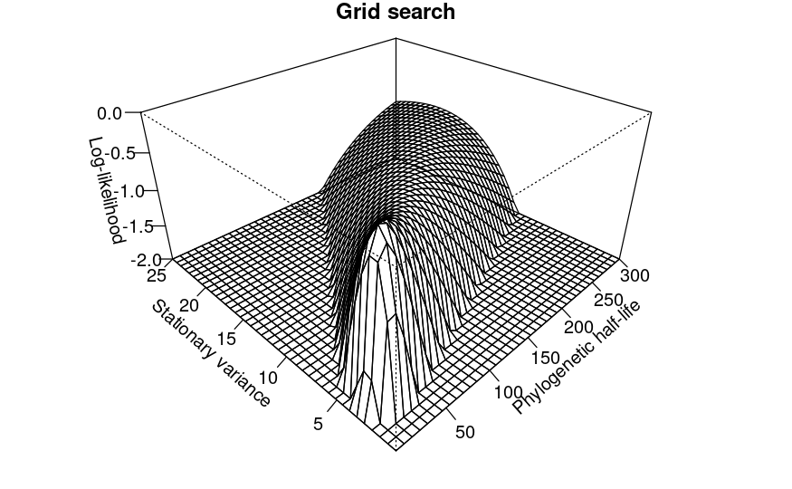

```r
plot(slouch_gridsearch, theta=-45)
```

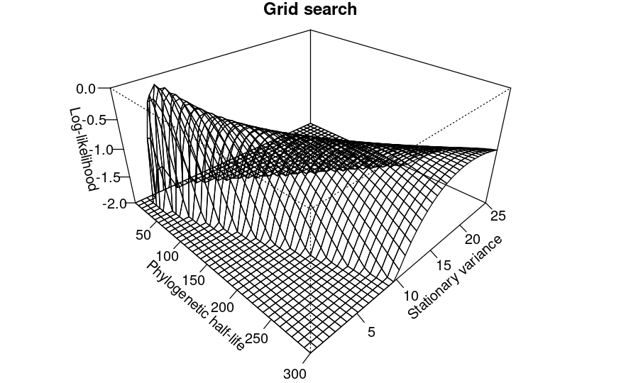

```r
plot(slouch_gridsearch, theta=45)
```

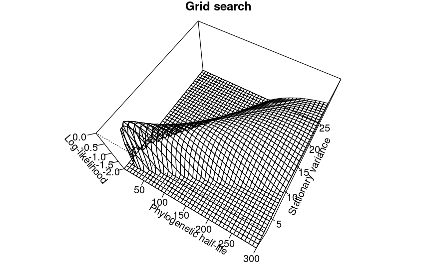

```r
plot(slouch_gridsearch, phi=60)
```